# Machine Learning in Political Science: Project Memo

Adaline Powell

2025-04-23

# Introductions

In this memo, I apply an unsupervised machine learning approach to open-ended responses from a survey on political behaviors and attitudes. Specifically, I aim to identify topics that emerge when respondents explain why they hold a particular level of partisan strength. Open-ended questions have major drawbacks in that they come with a lot of complexity, and it isn’t always easy for researchers to comb through a large number of responses. With the presence of time constraints, machine learning allows for a quicker approach to comb through all of the responses and identify natural clustering without bias. Applying a machine learning approach has a lot of benefits in this situation. One of the main ones is that it helps with the time constraints that come from having to go through every single response. Structural Topic Modeling, in particular, gives us a faster way to sort through the open-ended answers and pick up on common patterns and themes. # Data and Method

Data will be taken from a online survey distributed through Lucid. Participation was voluntary and respondents were provided compensation. In the survey, an experimental design is included and conducted on the partisan strength variable. It manipulates the wording in the second branch of questioning (normal format follows the ANES) and replaces it with softer phrasing, a method commonly used to reduce the effects of social desirability. The survey also includes questions on self-monitoring and age. The main question of concern is an open-ended question that asks respondents to describe what makes them a “strong” or “not-so-strong” Democrat or Republican.

I will be using Structural Topic Modeling (Roberts et. al, 2014) in order to create topics. This form of modeling allows me to include covariates that I believe will play a role in how the respondents answer these questions. The covariates that I believe will affect the content of these responses include age, self-monitoring, and partisan strength.

# Cleaning the Responses

The first step I need to take before running the model is cleaning the responses. textProcessor is a function that cleans the responses by converting words to lowercase, removing stop words, numbers, and punctuation. plotRemoved is a function that provides a visual of three plots: number of words, number of documents, and total number of tokens removed as a function of threshold values. The threshold is the minimum number of documents a word must appear in. Based on that, the y-axis shows how many documents, words, and tokens are removed.

```r
set.seed(23456)
processed <- textProcessor(documents = survey$WMY, metadata = survey)
```

```
## Building corpus...
## Converting to Lower Case...
## Removing punctuation...
## Removing stopwords...
## Removing numbers...
## Stemming...
## Creating Output...
```

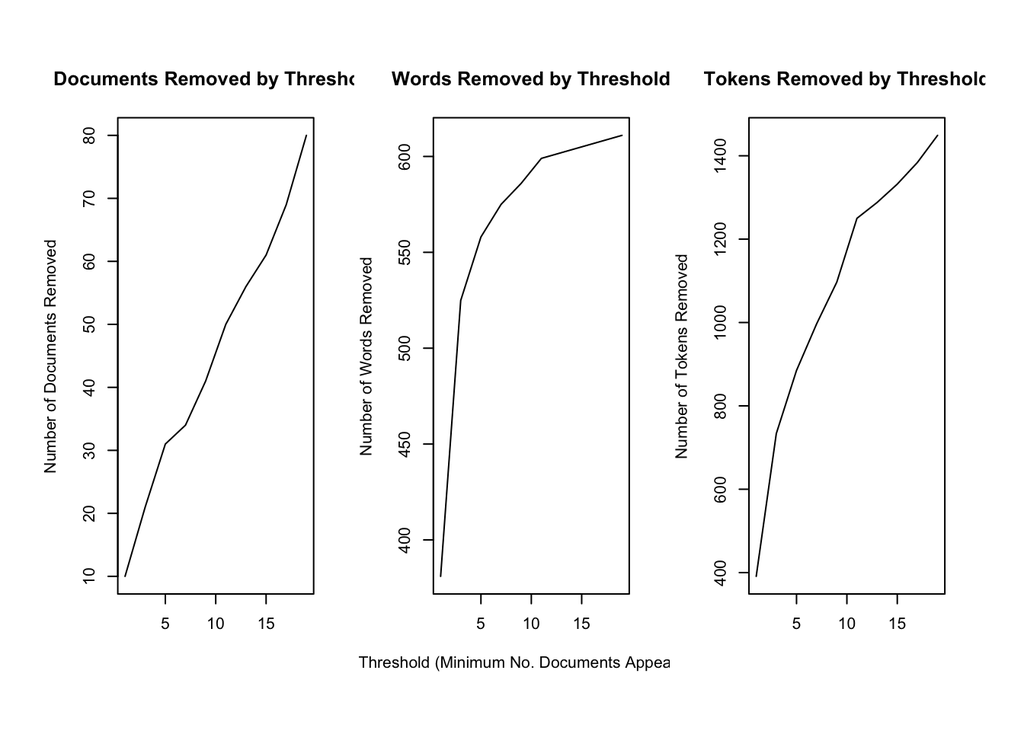

```r
plotRemoved(processed$documents, lower.thresh = seq(1, 20, by = 2))
```

Next I prepare my data to fit an appropriate form to run a Structual topic model, removing words that appear in fewer than 2 documents. I used a threshold of 2 because of the shorter length of these responses.

```r
out <- prepDocuments(
  documents = processed$documents,
  vocab = processed$vocab,
  meta = processed$meta,
  lower.thresh = 2
)
```

```
## Removing 483 of 627 terms (585 of 1967 tokens) due to frequency
## Removing 15 Documents with No Words
## Your corpus now has 354 documents, 144 terms and 1382 tokens.
```

```r
docs <- out$documents
vocab <- out$vocab
meta <- out$meta
```

# The Model

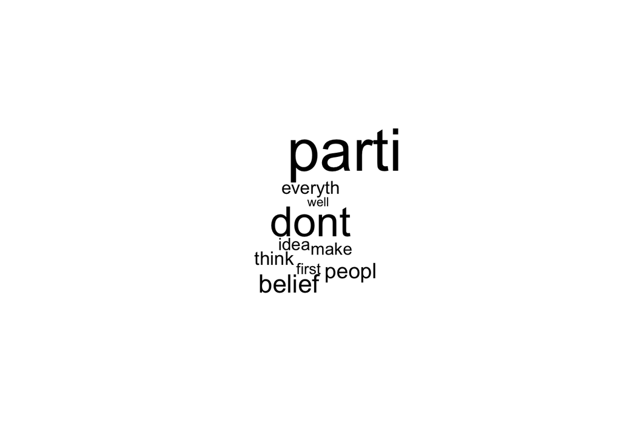

```r
cloud(modell, topic = 1, max.words = 10)
```

I can also compare the expected topic proportions and their top words. Topic 5 appears to have the highest proportion with the top words being believe, vote and agree.

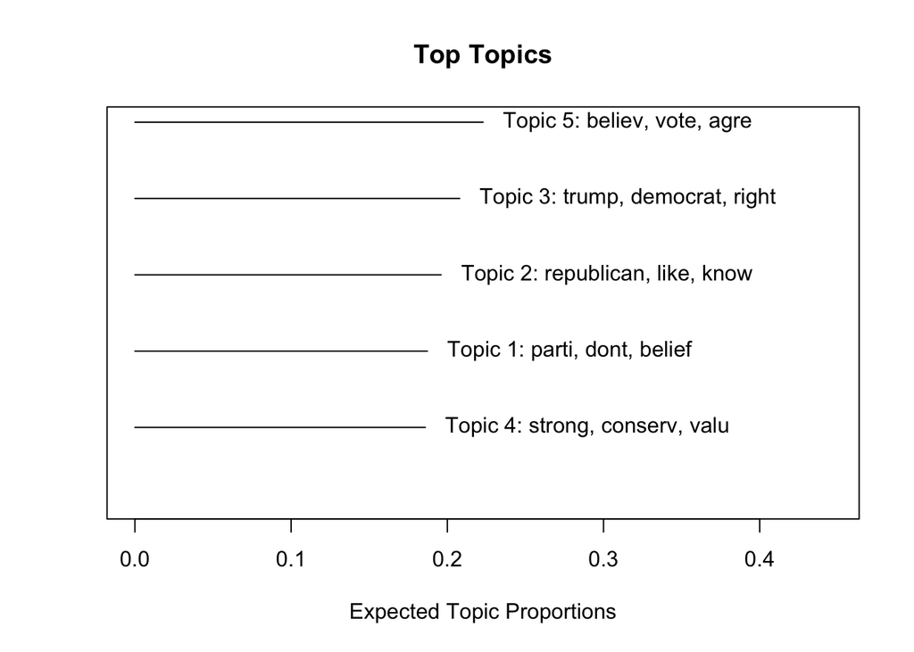

In order to visual the term probability within each topic, I can create a matrix.

```r
tidy_stm <- tidy(modell, matrix = "beta")
```

According to the figure below:

- Topic 1: parti, dont, belief
- Topic 2: republican, like, know
- Topic 3: trump, democrat, right
- Topic 4: strong, conserv, valu
- Topic 5: believ, vote, agre

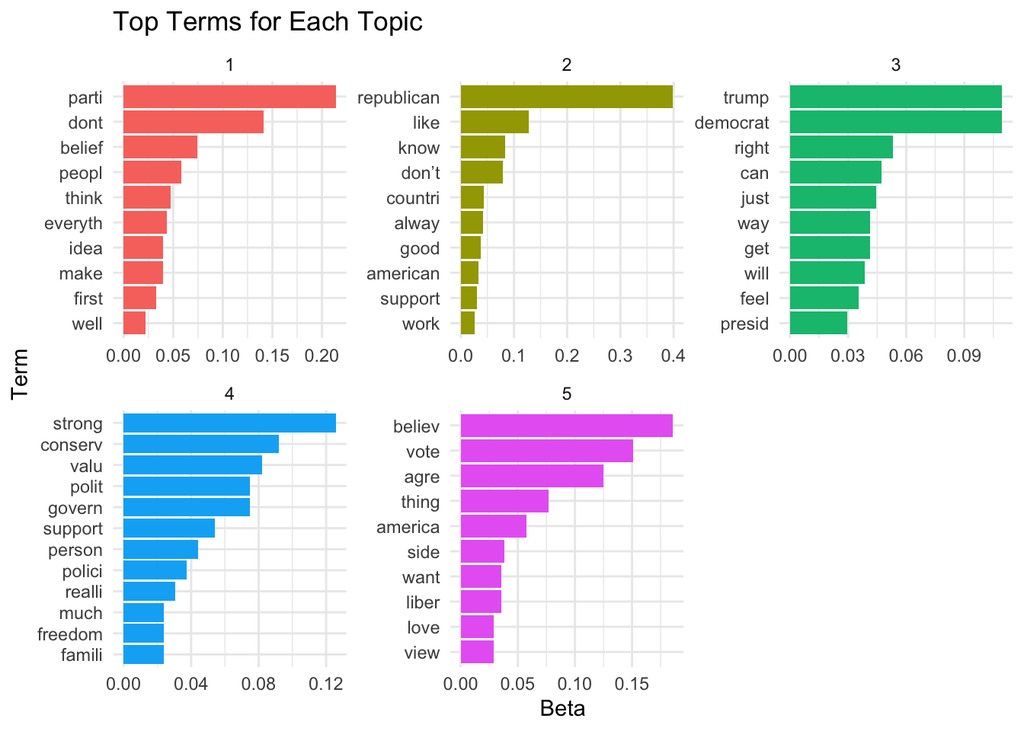

# Covarties

After controlling for age, part, and partisan strength, slightly different topics emerge.

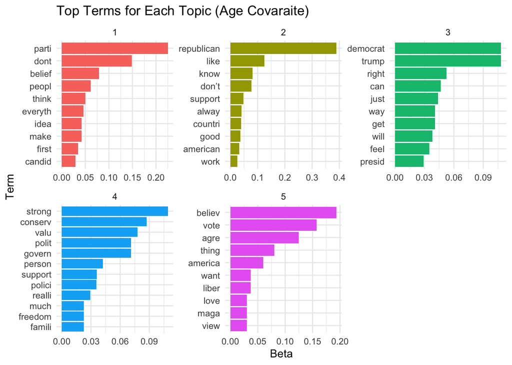

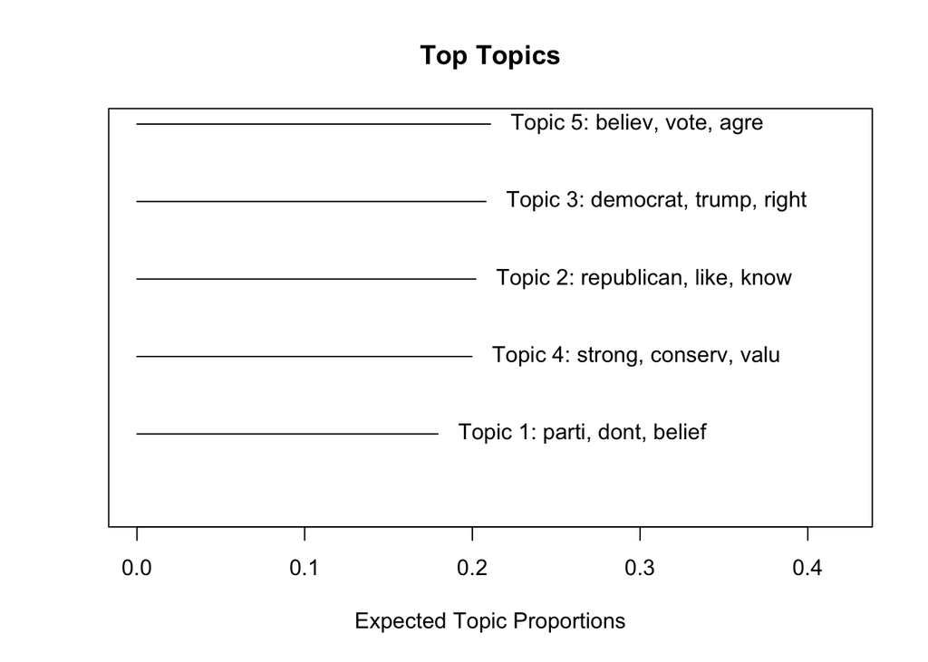

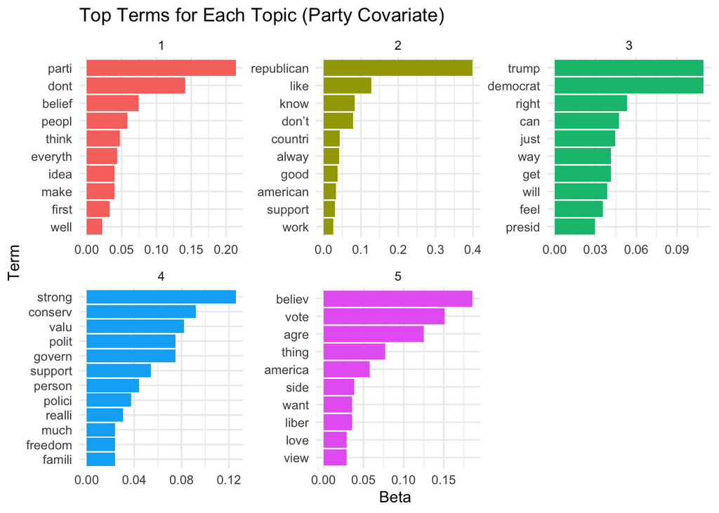

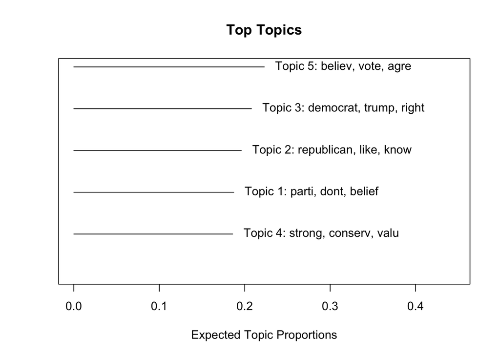

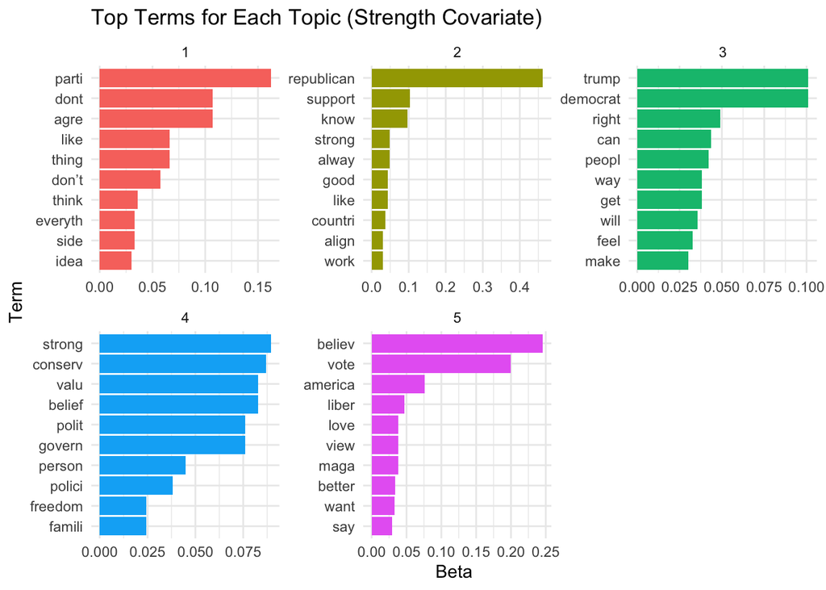

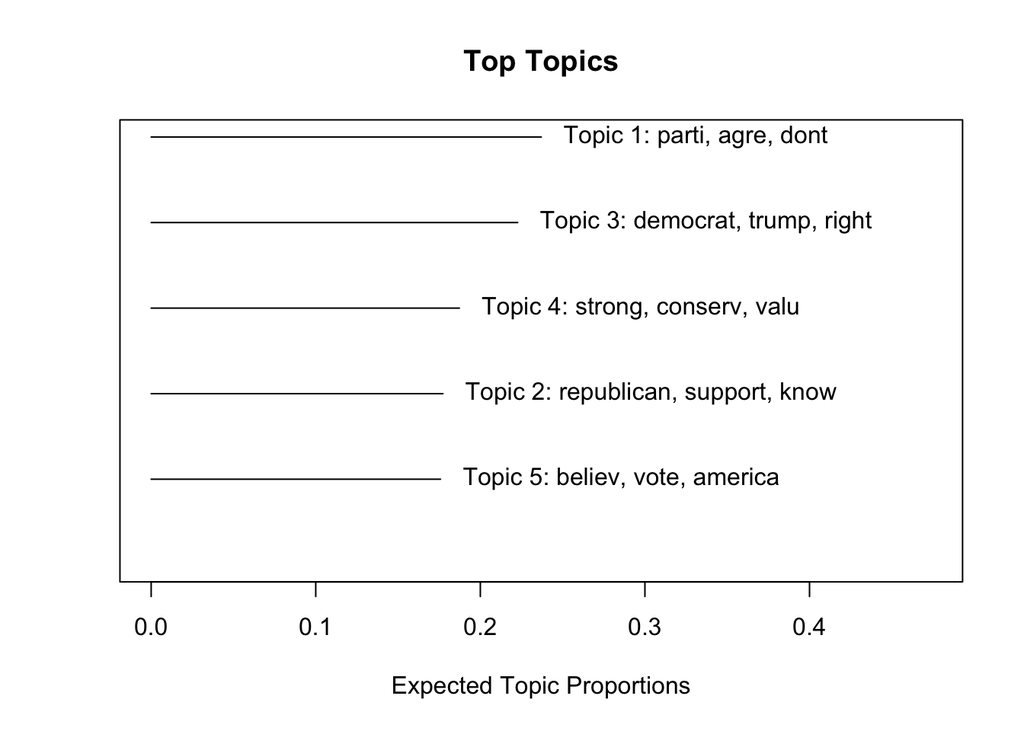

When controlling for age, the topic with the highest expected proportion is Topic 5, which includes the words believe, vote, and agree. The remaining topics have relatively similar proportions. Topic 3 contains terms like Democrat, Trump, and right; Topic 2 includes Republican, like, and know; and Topic 4 features strong, conservative, and value.

When controlling for party, Topic 5 again includes the words believe, vote, and agree, consistent with the results from the age covariate model. Topic 3 focuses on Democrat, Trump, and right, while Topic 2 includes Republican, like, and know. Topic 1 contains party, don’t, and belief, and Topic 4 again highlights strong, conservative, and value. These topics all appear with roughly similar expected proportions.

When accounting for partisan strength, Topic 1 shows the highest expected topic proportion, including terms like party, agree, and don’t. It is followed by Topic 3 (Democrat, Trump, right) and Topic 4 (strong, conservative, value). Topic 2 contains Republican, support, and no, while Topic 5 includes believe, vote, and America.

# Discussion

Overall, the results suggest the topic that dominates when controlling for age and party has top words including believe, vote, and agree. When asked what makes respondents a specific level of partisan strength, they tend to resort to themes of civic engagement and are belief orientated. However, when controlling for partisan strength, a topic with terms such as party, agree, and don’t becomes more prevalent. Therefore, when considering respondents’ partisan strengths, the topics that emerge to explain their self-identified strength often center around discussions of party affiliation, and agreement or disagreement.

# Conclusion

Open-ended questions have major drawbacks because they come with a lot of complexity, and it isn’t always easy for researchers to comb through a large number of responses. Due to time constraints, machine learning allows for a quicker approach to comb through all of the responses and identify natural clustering without bias. This approach would be particularly beneficial when interested in first hand accounts on any particular political issue and policy implementation. However, a drawback to this approach is that the terms alone do not provide a complete picture of the responses. Furthermore, the terms ‘party’ and ‘belief’ occurring together can imply multiple meanings, therefore, additional research may be necessary to understand the responses more thoroughly.

### Sources

- https://rpubs.com/hsuemrosen/basic-stm-demo
- https://cran.r-project.org/web/packages/stm/vignettes/stmVignette.pdf
- https://cran.r-project.org/web/packages/stm/index.html
- https://warin.ca/shiny/stm/#section-ingest
- Roberts, M. E., Stewart, B. M., & Tingley, D. (2019). stm: An R Package for Structural Topic Models. Journal of Statistical Software, 91(2), 1–40. https://doi.org/10.18637/jss.v091.i02